| title: “Machine Learning Course Project” |
| --- |
| author: “AMR” |
| date: “December 14, 2017” |
| output: |
| html_document: default |
| md_document : default |

## Executive summary

The goal of your project is to predict the manner in which the participants did their exercise (correctly or incorrectly). This is the “classe” variable in the training set.

Two prediction models, classification trees and random forest, are compared in order to find out which model performs best in predicting the manner in which the participants did their exercise.

This report describe how the prediction models were built, and how cross validation was conducted.

As a result, this project shows that the random forest model performs better that the classification trees in predicting the manner in which the participants did their exercise.

## Backgroung

Using devices such as *Jawbone Up, Nike FuelBand,* and *Fitbit* it is now possible to collect a large amount of data about personal activity relatively inexpensively. These type of devices are part of the quantified self movement - a group of enthusiasts who take measurements about themselves regularly to improve their health, to find patterns in their behavior, or because they are tech geeks. One thing that people regularly do is quantify how much of a particular activity they do, but they rarely quantify how well they do it. In this project, your goal will be to use data from accelerometers on the belt, forearm, arm, and dumbell of 6 participants. They were asked to perform barbell lifts correctly and incorrectly in 5 different ways. More information is available from the website here: http://groupware.les.inf.puc-rio.br/har (see the section on the Weight Lifting Exercise Dataset).

## Loading and cleaning the data

```r
# import the data from the URLs

# trainurl <- "https://d396qusza40orc.cloudfront.net/predmachlearn/pml-training.csv"
# testurl <- "https://d396qusza40orc.cloudfront.net/predmachlearn/pml-testing.csv"
# training <- download.file(trainurl, "training.csv")
# testing <- download.file(testurl, "testing.csv")

# load the data locally
training <- read.csv("training.csv", na.strings = c("NA", ""))
testing <- read.csv("testing.csv", na.strings = c("NA", ""))

# deleting columns (predictors) that contain any missing values
training <- training[, colSums(is.na(training)) == 0]
testing <- testing[, colSums(is.na(testing)) == 0]
```

## Splitting the training data set for out-of-sample errors

In order to get out-of-sample errors, we need to split the training set into train data set (train, 70%) for prediction and a validation data set (valid 30%)

```r
# splitting the training data set:

set.seed(123)
inTrain <- createDataPartition(training$classe, p = 0.7, list = FALSE)
train <- training[inTrain, ]
valid <- training[-inTrain, ]
```

## Using two prediction models: classification trees and random forest

### Classification trees model

We use here a 5-fold cross validation (default setting in trainControl function is 10) to save a computing time.

```r
control <- trainControl(method = "cv", number = 5)
fit_rpart <- train(classe ~ ., data = train, method = "rpart",
                   trControl = control)
print(fit_rpart, digits = 4)
```

```
## CART
##
## 13737 samples
##    59 predictor
##     5 classes: 'A', 'B', 'C', 'D', 'E'
##
## No pre-processing
## Resampling: Cross-Validated (5 fold)
## Summary of sample sizes: 10989, 10991, 10989, 10990, 10989
## Resampling results across tuning parameters:
##
##   cp      Accuracy  Kappa
##   0.2437  0.7662    0.7029
##   0.2568  0.5513    0.4263
##   0.2704  0.3617    0.1325
##
## Accuracy was used to select the optimal model using  the largest value.
## The final value used for the model was cp = 0.2437.
```

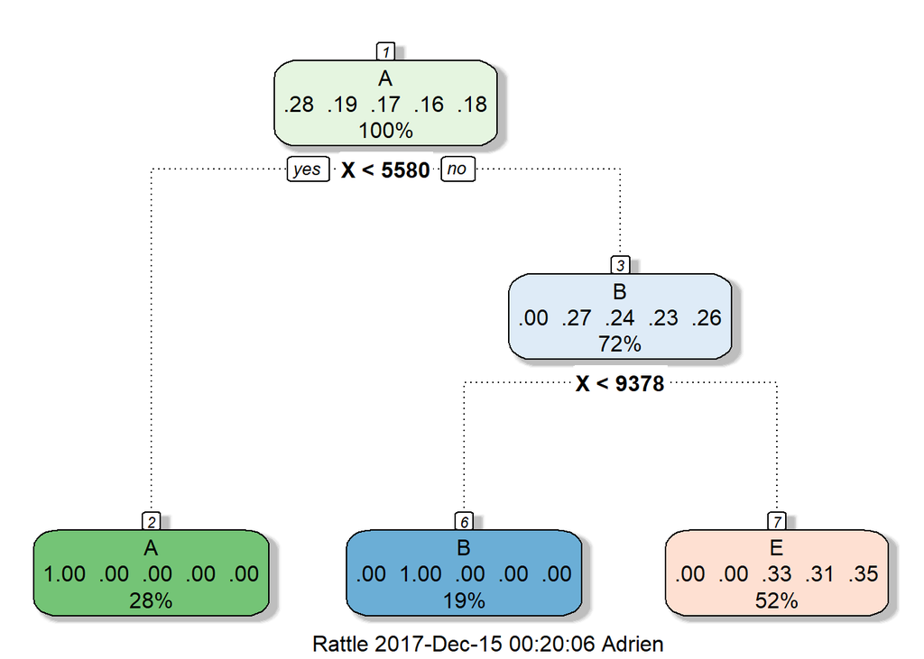

```r
# plotting the classification trees
fancyRpartPlot(fit_rpart$finalModel)
```

```r
# predicting the outcomes with the classification trees model using the validation data set
predict_rpart <- predict(fit_rpart, valid)
# Showing the confusion matrix
confusionMatrix(predict_rpart, valid$classe)
```

```
## Confusion Matrix and Statistics
##
##           Reference
## Prediction    A    B    C    D    E
##          A 1674    0    0    0    0
##          B    0 1139    0    0    0
##          C    0    0    0    0    0
##          D    0    0    0    0    0
##          E    0    0 1026  964 1082
##
## Overall Statistics
##
##                Accuracy : 0.6619
##                  95% CI : (0.6496, 0.6739)
##     No Information Rate : 0.2845
##     P-Value [Acc > NIR] : < 2.2e-16
##
##                   Kappa : 0.5696
##  Mcnemar's Test P-Value : NA
##
## Statistics by Class:
##
##                      Class: A Class: B Class: C Class: D Class: E
## Sensitivity            1.0000   1.0000   0.0000   0.0000   1.0000
## Specificity            1.0000   1.0000   1.0000   1.0000   0.5857
## Pos Pred Value         1.0000   1.0000      NaN      NaN   0.3522
## Neg Pred Value         1.0000   1.0000   0.8257   0.8362   1.0000
## Prevalence             0.2845   0.1935   0.1743   0.1638   0.1839
## Detection Rate         0.2845   0.1935   0.0000   0.0000   0.1839
## Detection Prevalence   0.2845   0.1935   0.0000   0.0000   0.5220
## Balanced Accuracy      1.0000   1.0000   0.5000   0.5000   0.7928
```

As we can see under the overall statistics, the accuracy of the classification trees model is: 0.6619

### Random forest Model

Now we try the random forest model:

```r
fit_rf <- train(classe ~ ., data = train, method = "rf",
                   trControl = control)
print(fit_rf, digits = 4)
```

```
## Random Forest
##
## 13737 samples
##    59 predictor
##     5 classes: 'A', 'B', 'C', 'D', 'E'
##
## No pre-processing
## Resampling: Cross-Validated (5 fold)
## Summary of sample sizes: 10990, 10989, 10991, 10989, 10989
## Resampling results across tuning parameters:
##
##   mtry  Accuracy  Kappa
##    2    0.9939    0.9923
##   41    0.9999    0.9999
##   81    0.9997    0.9996
##
## Accuracy was used to select the optimal model using  the largest value.
## The final value used for the model was mtry = 41.
```

```r
# predicting the outcomes with the random forest model using the validation data set
predict_rf <- predict(fit_rf, valid)

# Showing the confusion matrix of the random forest model
confusionMatrix(predict_rf, valid$classe)
```

```
## Confusion Matrix and Statistics
##
##           Reference
## Prediction    A    B    C    D    E
##          A 1674    0    0    0    0
##          B    0 1139    1    0    0
##          C    0    0 1025    0    0
##          D    0    0    0  964    0
##          E    0    0    0    0 1082
##
## Overall Statistics
##
##                Accuracy : 0.9998
##                  95% CI : (0.9991, 1)
##     No Information Rate : 0.2845
##     P-Value [Acc > NIR] : < 2.2e-16
##
##                   Kappa : 0.9998
##  Mcnemar's Test P-Value : NA
##
## Statistics by Class:
##
##                      Class: A Class: B Class: C Class: D Class: E
## Sensitivity            1.0000   1.0000   0.9990   1.0000   1.0000
## Specificity            1.0000   0.9998   1.0000   1.0000   1.0000
## Pos Pred Value         1.0000   0.9991   1.0000   1.0000   1.0000
## Neg Pred Value         1.0000   1.0000   0.9998   1.0000   1.0000
## Prevalence             0.2845   0.1935   0.1743   0.1638   0.1839
## Detection Rate         0.2845   0.1935   0.1742   0.1638   0.1839
## Detection Prevalence   0.2845   0.1937   0.1742   0.1638   0.1839
## Balanced Accuracy      1.0000   0.9999   0.9995   1.0000   1.0000
```

As we can see under the overall statistics, the accuracy of the random forest model is: 0.9998.

## Prediction with the random forest model on the testing data set

```r
predict_rfTest <- predict(fit_rf, testing)
predict_rfTest
```

```
##  [1] A A A A A A A A A A A A A A A A A A A A
## Levels: A B C D E
```

## Conclusion

This project shows that the random forest model performs better that the classification trees in predicting the manner in which the participants did their exercise.